# Machine Learning Project

joez

November 7, 2016

https://liebniz.github.io/machinelearning/

### Problem Statement

Using devices such as Jawbone Up, Nike FuelBand, and Fitbit it is now possible to collect a large amount of data about personal activity relatively inexpensively. These type of devices are part of the quantified self movement - a group of enthusiasts who take measurements about themselves regularly to improve their health, to find patterns in their behavior, or because they are tech geeks. One thing that people regularly do is quantify how much of a particular activity they do, but they rarely quantify how well they do it. In this project, the goal will be to use data from accelerometers on the belt, forearm, arm, and dumbbell of 6 participants labeled. They were asked to perform barbell lifts correctly and incorrectly in 5 different ways labelled A-E.

Once an acceptable model is created, a prediction of 20 independent test cases will be made using the model. The predicted results will be submitted separately for grading.

### Download Input Data

Data is downloaded as shown below. The “training” data set will be partitioned into training and validation sets. The “testing” data set will be used to make actual predictions once a suitable model is determined.

```r
# load libraries and set seed in non-cached code snippet
# to avoid scoping issues
library(caret,warn.conflicts = F,quietly = T)
library(randomForest)
set.seed(12345) # set for all subsequent usages
```

```r
trainingCsv <- read.csv("https://d396qusza40orc.cloudfront.net/predmachlearn/pml-training.csv")

testingCsv <- read.csv("https://d396qusza40orc.cloudfront.net/predmachlearn/pml-testing.csv")
```

### Data Analysis

Taking a look at the data we see that there are many columns that contain empty values, NA’s, and junk (e.g., #DIV/0!). This data will have to be ignored.

```r
str(trainingCsv)
```

```
## 'data.frame':    19622 obs. of  160 variables:
##  $ X                       : int  1 2 3 4 5 6 7 8 9 10 ...
##  $ user_name               : Factor w/ 6 levels "adelmo","carlitos",..: 2 2 2 2 2 2 2 2 2 2 ...
##  $ raw_timestamp_part_1    : int  1323084231 1323084231 1323084231 1323084232 1323084232 1323084232 1323084232 1323084232 1323084232 1323084232 ...
##  $ raw_timestamp_part_2    : int  788290 808298 820366 120339 196328 304277 368296 440390 484323 484434 ...
##  $ cvtd_timestamp          : Factor w/ 20 levels "02/12/2011 13:32",..: 9 9 9 9 9 9 9 9 9 9 ...
##  $ new_window              : Factor w/ 2 levels "no","yes": 1 1 1 1 1 1 1 1 1 1 ...
##  $ num_window              : int  11 11 11 12 12 12 12 12 12 12 ...
##  $ roll_belt               : num  1.41 1.41 1.42 1.48 1.48 1.45 1.42 1.42 1.43 1.45 ...
##  $ pitch_belt              : num  8.07 8.07 8.07 8.05 8.07 8.06 8.09 8.13 8.16 8.17 ...
##  $ yaw_belt                : num  -94.4 -94.4 -94.4 -94.4 -94.4 -94.4 -94.4 -94.4 -94.4 -94.4 ...
##  $ total_accel_belt        : int  3 3 3 3 3 3 3 3 3 3 ...
##  $ kurtosis_roll_belt      : Factor w/ 397 levels "","-0.016850",..: 1 1 1 1 1 1 1 1 1 1 ...
##  $ kurtosis_picth_belt     : Factor w/ 317 levels "","-0.021887",..: 1 1 1 1 1 1 1 1 1 1 ...
##  $ kurtosis_yaw_belt       : Factor w/ 2 levels "","#DIV/0!": 1 1 1 1 1 1 1 1 1 1 ...
```

[output cut: 86 more lines]

The data is loaded into excel where it is easily determined which columns contain acceptable data. In addition to NA’s and empty values, columns containing time stamps or artificial id’s (sequence numbers) are to be ignored as they are not relevant to the prediction.

Using favorite text editor, the following list of variables is determined:

```r
colNames = c("roll_belt", "pitch_belt",
  "yaw_belt", "total_accel_belt", "gyros_belt_x",
  "gyros_belt_y", "gyros_belt_z", "accel_belt_x",
  "accel_belt_y", "accel_belt_z", "magnet_belt_x",
  "magnet_belt_y", "magnet_belt_z", "roll_arm",
  "pitch_arm", "yaw_arm", "total_accel_arm", "gyros_arm_x",
  "gyros_arm_y",  "gyros_arm_z", "accel_arm_x", "accel_arm_y",
  "accel_arm_z", "magnet_arm_x",  "magnet_arm_y", "magnet_arm_z",
  "roll_dumbbell", "pitch_dumbbell", "yaw_dumbbell",
  "total_accel_dumbbell", "gyros_dumbbell_x", "gyros_dumbbell_y",
  "gyros_dumbbell_z", "accel_dumbbell_x", "accel_dumbbell_y",
  "accel_dumbbell_z", "magnet_dumbbell_x", "magnet_dumbbell_y",
  "magnet_dumbbell_z", "roll_forearm", "pitch_forearm",
  "yaw_forearm", "gyros_forearm_x", "gyros_forearm_y",
  "gyros_forearm_z",  "accel_forearm_x", "accel_forearm_y",
  "accel_forearm_z", "magnet_forearm_x", "magnet_forearm_y",
  "magnet_forearm_z")
```

The data is filtered based on these column names. The “classe” column is included in the training set as this is our classifier for prediction.

```r
# save till end of project
testingReduced <- subset(testingCsv,select = colNames)

# include the "classe" column
trainingReduced <- subset(trainingCsv,select = c("classe", colNames))
```

### Splitting

As per the idiom from class notes/slides, the input data is split into training and testing partitions using the createDataPartion() function from the caret package.

```r
inTrain <- createDataPartition(y=trainingReduced$classe, p=0.7, list=FALSE)

training <- trainingReduced[inTrain,]
testing <- trainingReduced[-inTrain,]
dim(training)
```

```
## [1] 13737    52
```

```r
dim(testing)
```

```
## [1] 5885   52
```

We now have clean data and are ready to start modeling.

### Model Selection

Since this is a classification problem, CART (Classification and Regression Trees) and Random Forest are reasonable approaches for modeling. In addition to class notes, this article was used for ideas.

https://www.r-bloggers.com/a-brief-tour-of-the-trees-and-forests/

#### rpart

Starting with recursive partitioning and regression trees (rpart), the following model is produced.

```r
modelRPart <- train(classe ~ ., data=training, method="rpart")
```

The model is now used to predict from the testing data partition.

```r
predictRPart <- predict(modelRPart, newdata = testing)
```

Comparing predicted values with original test data via the confusion matrix:

```r
cm <- confusionMatrix(predictRPart, testing$classe)
cm
```

```
## Confusion Matrix and Statistics
##
##           Reference
## Prediction    A    B    C    D    E
##          A 1494  470  467  438  141
##          B   21  380   29  184  147
##          C  128  289  530  342  277
##          D    0    0    0    0    0
##          E   31    0    0    0  517
##
## Overall Statistics
##
##                Accuracy : 0.4963
##                  95% CI : (0.4835, 0.5092)
##     No Information Rate : 0.2845
##     P-Value [Acc > NIR] : < 2.2e-16
##
##                   Kappa : 0.3425
##  Mcnemar's Test P-Value : NA
##
## Statistics by Class:
##
##                      Class: A Class: B Class: C Class: D Class: E
## Sensitivity            0.8925  0.33363  0.51657   0.0000  0.47782
## Specificity            0.6400  0.91972  0.78679   1.0000  0.99355
## Pos Pred Value         0.4963  0.49934  0.33844      NaN  0.94343
## Neg Pred Value         0.9374  0.85187  0.88516   0.8362  0.89414
## Prevalence             0.2845  0.19354  0.17434   0.1638  0.18386
## Detection Rate         0.2539  0.06457  0.09006   0.0000  0.08785
## Detection Prevalence   0.5115  0.12931  0.26610   0.0000  0.09312
## Balanced Accuracy      0.7662  0.62667  0.65168   0.5000  0.73568
```

and specifically the model accuracy

```r
cm$overall["Accuracy"]
```

```
##  Accuracy
## 0.4963466
```

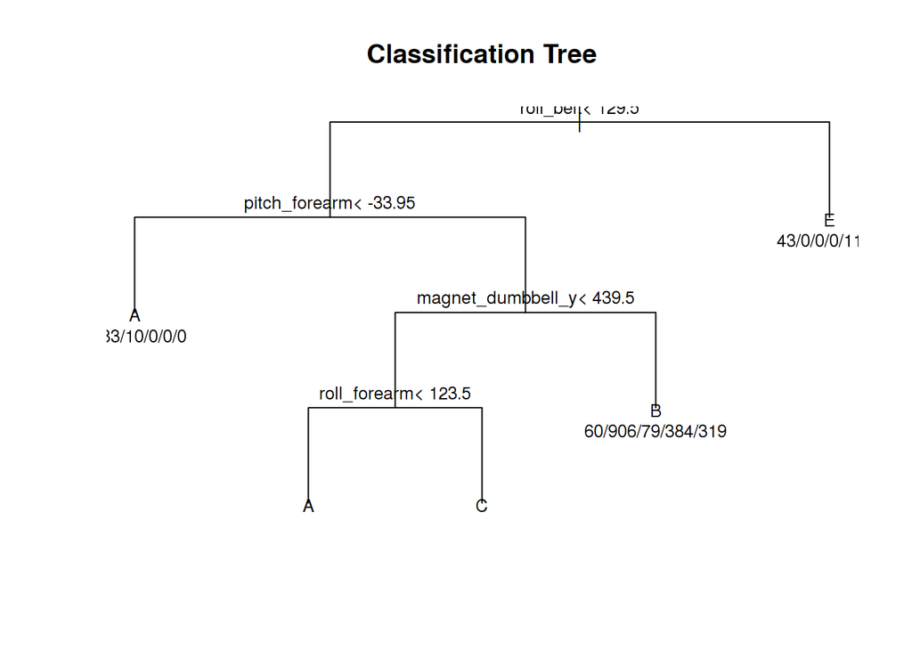

```r
plot(modelRPart$finalModel, uniform=T, main="Classification Tree")
text(modelRPart$finalModel, use.n=T, cex=.8)
```

#### Random Forest

Now the Random Forest approach as used - it’s hallmark is accuracy. While running the train(model=“rf”) function, ran into performance issues. Please refer to the following article which suggests several performance improvements. Most notably, “bagging” (sorry) formulas as they are parsed and evaluated very inefficiently.

http://stackoverflow.com/questions/15321947/problematic-random-forest-training-runtime-when-using-formula-interface

Using 1000 trees, the model is calculated and the test data partition is used to predict outcome.

```r
# Random Forest
# using train("rf") was too slow - did not complete

#modelRF <- train(classe ~ ., data=training, method="rf")

# x = predictors (everything except classe),
# y = classifier

modelRF <- randomForest(x=training[,-1],y = training$classe,
                        ntree = 1000, do.trace = F)

predictRF <- predict(modelRF, newdata = testing)
```

Comparing predicted values with original test data via the confusion matrix:

```r
cm <- confusionMatrix(predictRF, testing$classe)
cm
```

```
## Confusion Matrix and Statistics
##
##           Reference
## Prediction    A    B    C    D    E
##          A 1673    9    0    0    0
##          B    1 1127   12    0    0
##          C    0    3 1014   13    0
##          D    0    0    0  951    5
##          E    0    0    0    0 1077
##
## Overall Statistics
##
##                Accuracy : 0.9927
##                  95% CI : (0.9902, 0.9947)
##     No Information Rate : 0.2845
##     P-Value [Acc > NIR] : < 2.2e-16
##
##                   Kappa : 0.9908
##  Mcnemar's Test P-Value : NA
##
## Statistics by Class:
##
##                      Class: A Class: B Class: C Class: D Class: E
## Sensitivity            0.9994   0.9895   0.9883   0.9865   0.9954
## Specificity            0.9979   0.9973   0.9967   0.9990   1.0000
## Pos Pred Value         0.9946   0.9886   0.9845   0.9948   1.0000
## Neg Pred Value         0.9998   0.9975   0.9975   0.9974   0.9990
## Prevalence             0.2845   0.1935   0.1743   0.1638   0.1839
## Detection Rate         0.2843   0.1915   0.1723   0.1616   0.1830
## Detection Prevalence   0.2858   0.1937   0.1750   0.1624   0.1830
## Balanced Accuracy      0.9986   0.9934   0.9925   0.9927   0.9977
```

and specifically the model accuracy

```r
cm$overall["Accuracy"]
```

```
##  Accuracy
## 0.9926933
```

The GINI values are plotted as follows

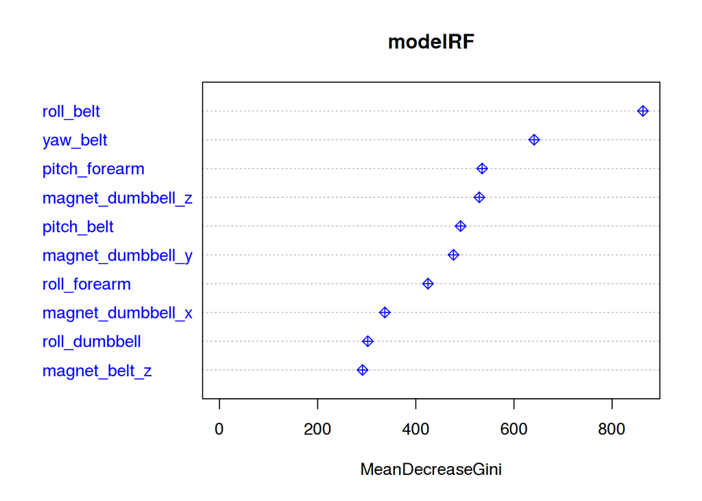

```r
varImpPlot(modelRF,n.var = 10,pch=9,col="blue")
```

The order of important variables are slightly different than from the CART model. In this case roll_belt, yaw_belt, pitch_forearm are the top three.

The accuracy is 99.2% (very impressive). This model will be used to predict the 20 test cases.

#### Predicting the Testing data

The 20 test cases are used for prediction using the random forest model.

```r
final <- predict(modelRF, newdata = testingReduced)

final
```

```
##  1  2  3  4  5  6  7  8  9 10 11 12 13 14 15 16 17 18 19 20
##  B  A  B  A  A  E  D  B  A  A  B  C  B  A  E  E  A  B  B  B
## Levels: A B C D E
```

Finally, the results are serialized to the workspace. This data will be used to create the results submission file offline.

```r
save(final, file = "final.Rdata")
```